# Amusement Park Injuries in TX, USA

Innocenter Amima

9/19/2019

# Introduction

Amusement park injuries data is from [data.world](https://data.world/amillerbernd/texas-amusement-park-accidents/workspace/file?filename=Amusement-Park-Injuries-xlsxCleaned.xls). This is part of the weekly #TidyTuesday project aimed at the R ecosystem on Twitter.

The data has a lot of text, inconsistent NAs and dates.

## Objectives

1. Clean the data
2. Perform EDA and Data viz

To achieve the objectives we shall answer the following questions

1. How many injuries were recorded per year, per month?
2. What kind of injuries were reported? What were the top causes of injuries?
3. Who were injured more? Children? Adults? Female/Girls? Male/Boys?

Loading packages

```r
library(tidyverse) #data manipulation
library(extrafont) #fonts
loadfonts(device = "win") #initializing
library(tidytext) #unnest text to tokens
library(stopwords) #for excuding stopwords from tokens
library(wordcloud) # to render wordclouds
library(janitor) #for data formating conversion of long/wide date types from excel
library(lubridate) #for date manipulation/formating
```

```r
tx_injuries <- readr::read_csv("https://raw.githubusercontent.com/rfordatascience/tidytuesday/master/data/2019/2019-09-10/tx_injuries.csv", na=c("", "N/A", "NA", "n/a", "na"))
```

```r
injuries <- tx_injuries #copy
glimpse(injuries)
```

```
## Observations: 542
## Variables: 13
## $ injury_report_rec <dbl> 2032, 1897, 837, 99, 55, 780, 253, 253, 55, ...
## $ name_of_operation <chr> "Skygroup Investments LLC DBA iFly Austin", ...
## $ city              <chr> "Austin", "Galveston", "Grapevine", "San Ant...
## $ st                <chr> "TX", "TX", "TX", "TX", "AZ", "TX", "TX", "T...
## $ injury_date       <chr> "2/12/2013", "3/2/2013", "3/3/2013", "3/3/20...
## $ ride_name         <chr> "I Fly", "Gulf Glider", "Howlin Tornado", "S...
## $ serial_no         <chr> "SV024", "GS-11-10-WG-14", "0643-C1-T1-TN60"...
## $ gender            <chr> "F", "F", "F", "F", "F", "F", "F", "M", "M",...
## $ age               <chr> "37", "43", NA, "51", "17", "40", "36", "23"...
## $ body_part         <chr> "Mouth", "Knee", "Right Shoulder", "Lower Le...
## $ alleged_injury    <chr> "Student hit mouth on wall", "Alleged arthro...
## $ cause_of_injury   <chr> "Student attempted unfamiliar manuever", "Hi...
## $ other             <chr> NA, "Prior history of problems with this kne...
```

```r
table((injuries$st))
```

```
##
##  AZ  FL  TX
##   5   1 536
```

```r
unique(injuries$gender)
```

```
## [1] "F" "M" NA  "m"
```

# Data Cleaning

> We shall drop data from the other states and only consider TX. Rename the two factors of gender and drop NA Date and age is a character, we shall convert to date type and numeric respectively

```r
#select TX state only given it has 99% of the data points
injuries %>%
  filter(st == "TX") -> injuries

#factor gender as M anf F using dplyr case_when and drop NAs
injuries <- injuries %>%
  mutate(gender = case_when(
    gender %in% c("F", "f") ~ "F",
    gender %in% c("M", "m") ~ "M")
        ) %>%
  drop_na(gender)

#convert age to numeric and drop nas

injuries <- injuries %>%
  mutate(age=as.numeric(age)) %>%
  filter(!is.na(age))
```

The date has two types - excel numeric and mdy format. Using a two-step process; I converted the date using the `janitor` package for the excel numeric and to dates from character using the `lubridate` package.

```r
#convert the excel numeric data format using janitor package

injuries$date_inj_excel <- excel_numeric_to_date(as.numeric(as.character(injuries$injury_date)))
#convert the dates to numeric using the lubridate package

injuries$date_inj <- parse_date_time(injuries$injury_date, orders = c("mdy"))
#combine the two columns

injuries %>%
  unite("date_final", date_inj:date_inj_excel) -> injuries

#remove the NA_ and _NA #using regexprs

injuries$datefinal <- sapply(injuries$date_final, function(x) gsub("NA_", "", x))
injuries$datefinal <- sapply(injuries$datefinal, function(x) gsub("_NA", "", x))

#parse as date
injuries$datefinal <- parse_date(injuries$datefinal)

#include year and month
injuries %>%
  mutate(year= lubridate::year(datefinal),
         month = lubridate::month(datefinal)
  ) -> injuries
```

## Data Viz

Here we determine how many injuries were recorded per month and per year. To analyse which months need extra attention because we expect more injurries in the park during summer compared to winter.

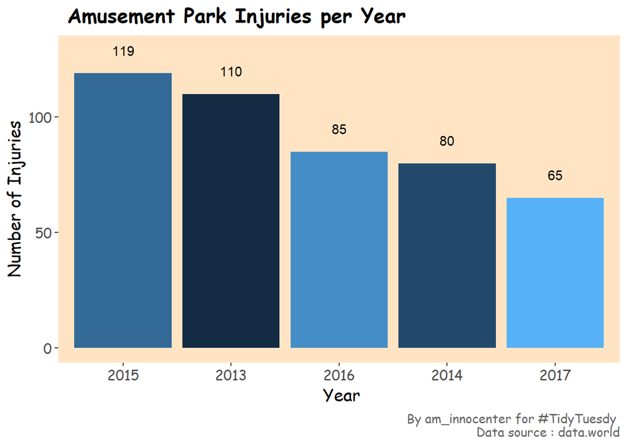

```r
#injuries per year
injuries %>%
  group_by(year) %>%
  tally() %>%
  ungroup() %>%
  drop_na() %>%
  ggplot(injuries, mapping=aes(reorder(year, -n), n , fill=year, label=n))+
    geom_col(show.legend = FALSE) +
    geom_text(nudge_y = 10) +
    labs(title= " Amusement Park Injuries per Year",
       caption = "By am_innocenter for #TidyTuesdy \n Data source : data.world", x= " Year", y="Number of Injuries" )+
  theme(panel.background = element_rect(fill="bisque")) + #, colour = "#6D9EC1")) +
  theme(text = element_text(family = "Comic Sans MS", size = 14),
        plot.caption = element_text( size=10, color = "grey40"),
        plot.title =element_text(size = 16, face="bold", vjust=1) )+
  theme(
    # Hide panel borders and remove grid lines
    panel.border = element_blank(),
    panel.grid.major = element_blank(),
    panel.grid.minor = element_blank()        ) +
  theme(legend.position = "none")
```

To answer how many injuries were recorded per month we utilized the `month.abb` built-in constant to rearrange months from Jan - Dec

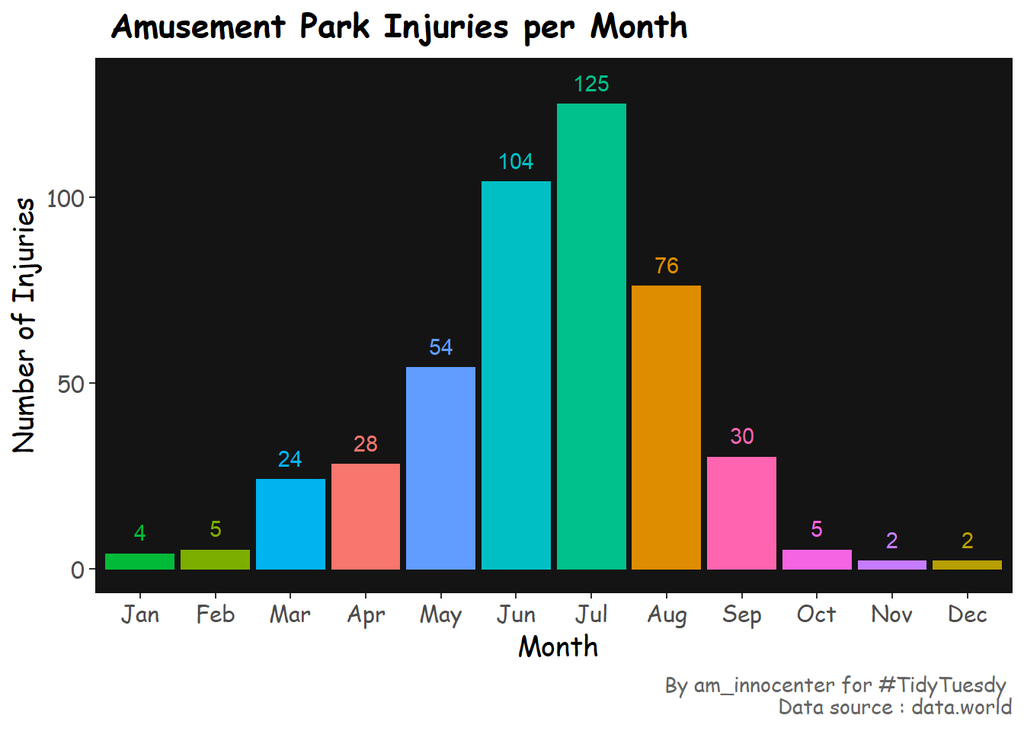

```r
#injuries per month

injuries %>%
  group_by(Months=month.abb[month]) %>% #built-in constant month.abb has 3-letter abbrev for the months
  tally() %>%
  ungroup() %>%
  drop_na() %>%
  ggplot(injuries, mapping=aes(Months, n , fill=Months, color=Months, label = n))+
    geom_col(show.legend = FALSE)  +
    geom_text(nudge_y = 6) +
    scale_x_discrete(limits= month.abb) + #rearranges the month order
    labs(title= " Amusement Park Injuries per Month",
         caption = "By am_innocenter for #TidyTuesdy \n Data source : data.world", x= " Month", y="Number of Injuries"
         )+
    theme(panel.background = element_rect(fill="gray8")) + #, colour = "#6D9EC1")) +
    theme(text = element_text(family = "Comic Sans MS", size = 14),
          plot.caption = element_text( size=10, color = "grey40"),
          plot.title =element_text(size = 16, face="bold", vjust=1) )+
    theme(
    # Hide panel borders and remove grid lines
    panel.border = element_blank(),
    panel.grid.major = element_blank(),
    panel.grid.minor = element_blank()        ) +
    theme(legend.position = "none")
```

As we had pre-empted, June-Aug has the highest number of injuries.

Who got injured more? Male or female? children or adults?

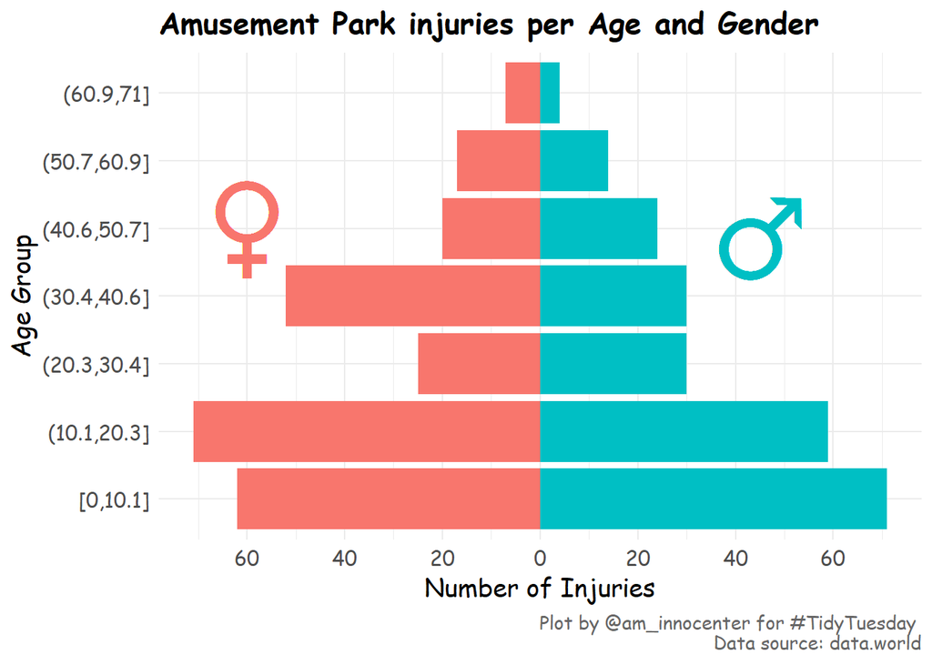

```r
injuries %>%
  select(gender,age) %>%
  filter(age>=0) %>%
  mutate(age_bins = cut_interval(age,7)) %>%
  group_by(gender, age_bins) %>%
  tally() %>%
  ungroup() %>%
  mutate(count= if_else(gender=="F", -n, n)) %>%
  ggplot(aes(x=age_bins, count , fill=gender))+
    geom_bar(stat = "identity", show.legend = FALSE) +
    coord_flip()+
    scale_y_continuous(breaks = seq(-60, 60, 20),
                       labels = c(seq(60,0,-20), seq(20,60,20)))+ #renaming y aesthetics
  labs(title= "Amusement Park injuries per Age and Gender",
       x="Age Group", y="Number of Injuries",
       caption = "Plot by @am_innocenter for #TidyTuesday \n Data source: data.world")+
  theme_minimal()+
  theme(text = element_text(family = "Comic Sans MS", size = 14),
        plot.caption = element_text( size=10, color = "gray40"),
        plot.title =element_text(size = 16, face="bold", vjust=1) ) +
  geom_text(aes(5,-60), label="\u2640", hjust = 0.5, size = 25,color = "#F8766D", family = "Comic Sans MS") +
  geom_text(aes(5,45), label="\u2642", hjust = 0.5, size = 25, color = "#00BFC4", family = "Comic Sans MS")
```

Trick I learned to pick the colors use `ggplot_build(plotname)`.

Children reported more injuries compared to adults. Females are slightly more by 5% compared to the males.

Analyse the cause of injuries and body parts affected below using `tidytext`.

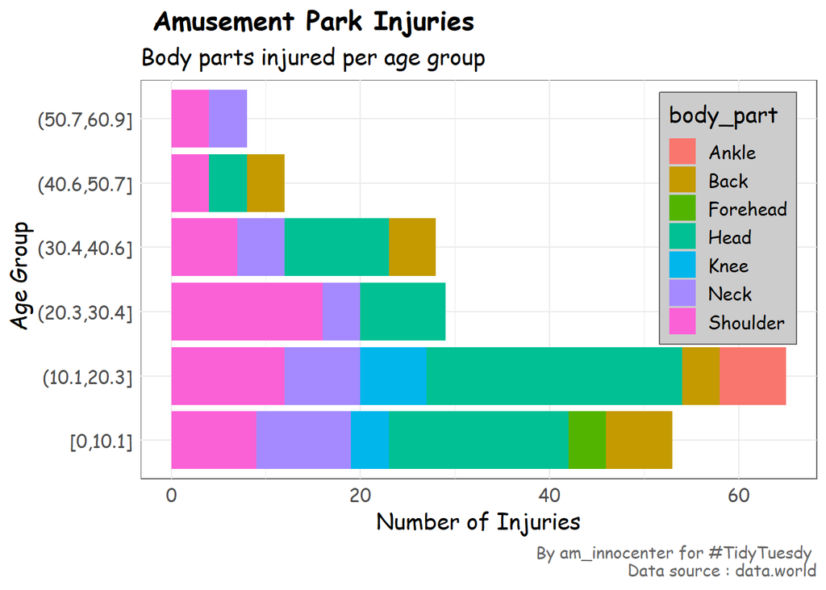

```r
injuries %>%
  select(gender,age , body_part) %>%
  mutate(age_bins = cut_interval(age,7)) %>%
  count(body_part,age_bins, sort = TRUE) %>%
  top_n(20) %>%
    ggplot(aes(age_bins,n, fill=body_part)) +
    geom_col() +
    coord_flip() +
    theme_minimal()+
    labs(title= " Amusement Park Injuries", subtitle = "Body parts injured per age group",
         caption = "By am_innocenter for #TidyTuesdy \n Data source : data.world", x= " Age Group", y="Number of Injuries" )+
    theme(panel.background = element_rect(color="grey40")) +
    theme(text = element_text(family = "Comic Sans MS", size = 14),
        plot.caption = element_text( size=10, color = "grey40"),
        plot.title =element_text(size = 16, face="bold", vjust=1) ) +
    theme(legend.position = c(.97, .97),legend.justification = c("right", "top"),
          legend.box.just = "right",
          legend.box.background = element_rect(fill="grey80", color="grey40"))
```

The most injured parts are head and shoulder among children and teenagers. For the elderly > 50 years it is the neck and shoulder. Most adults will be in the park taking care of the younger ones - the most injured body parts are shoulder and head.

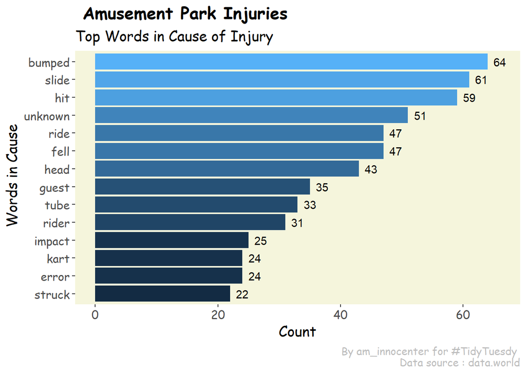

```r
injuries %>%
  select(cause_of_injury) %>%
  unnest_tokens(word, cause_of_injury) %>%
  anti_join(stop_words, by="word") %>%
  count(word, sort = TRUE) %>%
  ungroup() %>%
  filter(n > 20) %>%
  ggplot(mapping=aes(reorder(word,n), n, fill=n, label=n))+
    geom_col()+
    geom_text(nudge_y = 2) +
    coord_flip() +
    labs(title= " Amusement Park Injuries",
         subtitle = "Top Words in Cause of Injury",
         caption = "By am_innocenter for #TidyTuesdy \n Data source : data.world",
         x= " Words in Cause", y="Count")+
    theme(panel.background = element_rect(fill="beige")) +
    theme(text = element_text(family = "Comic Sans MS", size = 14),
          plot.caption = element_text( size=10, color = "grey"),
          plot.title =element_text(size = 16, face="bold", vjust=1) )+
    theme(
      # Hide panel borders and remove grid lines
      panel.border = element_blank(),
      panel.grid.major = element_blank(),
      panel.grid.minor = element_blank()        ) +
    theme(legend.position = "none")
```

I wanted to determine the words that occur commonly in pairs and how often sequence of word1 and word 2 occurs

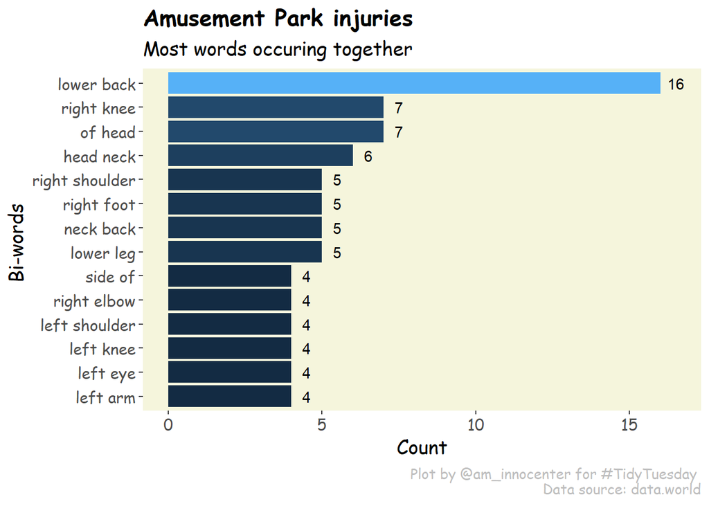

```r
#ngrams
injuries %>%
  unnest_tokens(biwords, body_part, token="ngrams", n=2) %>%
  count(biwords, sort=TRUE) %>%
  top_n(15) %>%
  filter(!is.na(biwords)) %>%
  ggplot(aes(reorder(biwords,n),n, fill= n, label=n))  +
    geom_col(show.legend = FALSE)+
    coord_flip() +
    geom_text(nudge_y = 0.5)+
    labs(title= "Amusement Park injuries", subtitle = "Most words occuring together",
       x="Bi-words ", y="Count",
       caption = "Plot by @am_innocenter for #TidyTuesday \n Data source: data.world") +
    theme(panel.background = element_rect(fill="beige")) +
    theme(text = element_text(family = "Comic Sans MS", size = 14),
          plot.caption = element_text( size=10, color = "grey"),
          plot.title =element_text(size = 16, face="bold", vjust=1) )+
    theme(
      # Hide panel borders and remove grid lines
      panel.border = element_blank(),
      panel.grid.major = element_blank(),
      panel.grid.minor = element_blank()        ) +
    theme(legend.position = "none")
```

#Learnings

> Converting excel numeric date format. Using tidytext, discovering janitor package,

In case you have feedback, questions, suggestions do not hesitate to leave a comment.